# Risk Factor Analysis

## Outcome Variable

**Outcome Variable:** whz

## Predictor Variables

**Intervention Variable:** predexfd6

**Adjustment Set:**

unadjusted

## Stratifying Variables

The analysis was stratified on these variable(s):

- agecat
- studyid
- country

## Data Summary

| agecat | studyid | country | predexfd6 | n_cell | n |
| --- | --- | --- | --- | --- | --- |
| Birth | CMC-V-BCS-2002 | INDIA | 1 | 7 | 7 |
| Birth | CMC-V-BCS-2002 | INDIA | 0 | 0 | 7 |
| Birth | EE | PAKISTAN | 1 | 24 | 28 |
| Birth | EE | PAKISTAN | 0 | 4 | 28 |
| Birth | GMS-Nepal | NEPAL | 1 | 390 | 522 |
| Birth | GMS-Nepal | NEPAL | 0 | 132 | 522 |
| Birth | IRC | INDIA | 1 | 0 | 12 |
| Birth | IRC | INDIA | 0 | 12 | 12 |
| Birth | JiVitA-3 | BANGLADESH | 1 | 8392 | 10744 |
| Birth | JiVitA-3 | BANGLADESH | 0 | 2352 | 10744 |
| Birth | JiVitA-4 | BANGLADESH | 1 | 1802 | 2224 |
| Birth | JiVitA-4 | BANGLADESH | 0 | 422 | 2224 |
| Birth | Keneba | GAMBIA | 1 | 450 | 1327 |
| Birth | Keneba | GAMBIA | 0 | 877 | 1327 |
| Birth | MAL-ED | BANGLADESH | 1 | 68 | 194 |
| Birth | MAL-ED | BANGLADESH | 0 | 126 | 194 |
| Birth | MAL-ED | BRAZIL | 1 | 5 | 57 |
| Birth | MAL-ED | BRAZIL | 0 | 52 | 57 |
| Birth | MAL-ED | INDIA | 1 | 4 | 37 |
| Birth | MAL-ED | INDIA | 0 | 33 | 37 |
| Birth | MAL-ED | NEPAL | 1 | 3 | 23 |
| Birth | MAL-ED | NEPAL | 0 | 20 | 23 |
| Birth | MAL-ED | PERU | 1 | 72 | 208 |
| Birth | MAL-ED | PERU | 0 | 136 | 208 |
| Birth | MAL-ED | SOUTH AFRICA | 1 | 1 | 90 |
| Birth | MAL-ED | SOUTH AFRICA | 0 | 89 | 90 |
| Birth | MAL-ED | TANZANIA, UNITED REPUBLIC OF | 1 | 0 | 105 |
| Birth | MAL-ED | TANZANIA, UNITED REPUBLIC OF | 0 | 105 | 105 |
| Birth | PROVIDE | BANGLADESH | 1 | 155 | 532 |
| Birth | PROVIDE | BANGLADESH | 0 | 377 | 532 |

[output cut: 70 more lines]

The following strata were considered:

- agecat: 24 months, studyid: CMC-V-BCS-2002, country: INDIA
- agecat: 24 months, studyid: EE, country: PAKISTAN
- agecat: 24 months, studyid: GMS-Nepal, country: NEPAL
- agecat: 24 months, studyid: IRC, country: INDIA
- agecat: 24 months, studyid: JiVitA-3, country: BANGLADESH
- agecat: 24 months, studyid: JiVitA-4, country: BANGLADESH
- agecat: 24 months, studyid: Keneba, country: GAMBIA
- agecat: 24 months, studyid: LCNI-5, country: MALAWI
- agecat: 24 months, studyid: MAL-ED, country: BANGLADESH
- agecat: 24 months, studyid: MAL-ED, country: BRAZIL
- agecat: 24 months, studyid: MAL-ED, country: INDIA
- agecat: 24 months, studyid: MAL-ED, country: NEPAL
- agecat: 24 months, studyid: MAL-ED, country: PERU
- agecat: 24 months, studyid: MAL-ED, country: SOUTH AFRICA
- agecat: 24 months, studyid: MAL-ED, country: TANZANIA, UNITED REPUBLIC OF
- agecat: 24 months, studyid: PROVIDE, country: BANGLADESH
- agecat: 6 months, studyid: CMC-V-BCS-2002, country: INDIA
- agecat: 6 months, studyid: EE, country: PAKISTAN
- agecat: 6 months, studyid: GMS-Nepal, country: NEPAL
- agecat: 6 months, studyid: IRC, country: INDIA
- agecat: 6 months, studyid: JiVitA-3, country: BANGLADESH
- agecat: 6 months, studyid: JiVitA-4, country: BANGLADESH
- agecat: 6 months, studyid: Keneba, country: GAMBIA
- agecat: 6 months, studyid: LCNI-5, country: MALAWI
- agecat: 6 months, studyid: MAL-ED, country: BANGLADESH
- agecat: 6 months, studyid: MAL-ED, country: BRAZIL
- agecat: 6 months, studyid: MAL-ED, country: INDIA
- agecat: 6 months, studyid: MAL-ED, country: NEPAL
- agecat: 6 months, studyid: MAL-ED, country: PERU
- agecat: 6 months, studyid: MAL-ED, country: SOUTH AFRICA
- agecat: 6 months, studyid: MAL-ED, country: TANZANIA, UNITED REPUBLIC OF
- agecat: 6 months, studyid: PROVIDE, country: BANGLADESH
- agecat: 6 months, studyid: SAS-CompFeed, country: INDIA
- agecat: 6 months, studyid: SAS-FoodSuppl, country: INDIA
- agecat: Birth, studyid: CMC-V-BCS-2002, country: INDIA
- agecat: Birth, studyid: EE, country: PAKISTAN
- agecat: Birth, studyid: GMS-Nepal, country: NEPAL
- agecat: Birth, studyid: IRC, country: INDIA
- agecat: Birth, studyid: JiVitA-3, country: BANGLADESH
- agecat: Birth, studyid: JiVitA-4, country: BANGLADESH
- agecat: Birth, studyid: Keneba, country: GAMBIA
- agecat: Birth, studyid: MAL-ED, country: BANGLADESH
- agecat: Birth, studyid: MAL-ED, country: BRAZIL
- agecat: Birth, studyid: MAL-ED, country: INDIA
- agecat: Birth, studyid: MAL-ED, country: NEPAL
- agecat: Birth, studyid: MAL-ED, country: PERU
- agecat: Birth, studyid: MAL-ED, country: SOUTH AFRICA
- agecat: Birth, studyid: MAL-ED, country: TANZANIA, UNITED REPUBLIC OF
- agecat: Birth, studyid: PROVIDE, country: BANGLADESH
- agecat: Birth, studyid: SAS-CompFeed, country: INDIA

### Dropped Strata

Some strata were dropped due to rare outcomes:

- agecat: Birth, studyid: CMC-V-BCS-2002, country: INDIA
- agecat: Birth, studyid: EE, country: PAKISTAN
- agecat: Birth, studyid: IRC, country: INDIA
- agecat: Birth, studyid: MAL-ED, country: INDIA
- agecat: Birth, studyid: MAL-ED, country: NEPAL
- agecat: Birth, studyid: MAL-ED, country: SOUTH AFRICA
- agecat: Birth, studyid: MAL-ED, country: TANZANIA, UNITED REPUBLIC OF
- agecat: 6 months, studyid: CMC-V-BCS-2002, country: INDIA
- agecat: 6 months, studyid: IRC, country: INDIA
- agecat: 6 months, studyid: MAL-ED, country: SOUTH AFRICA
- agecat: 6 months, studyid: MAL-ED, country: TANZANIA, UNITED REPUBLIC OF
- agecat: 6 months, studyid: SAS-FoodSuppl, country: INDIA
- agecat: 24 months, studyid: CMC-V-BCS-2002, country: INDIA
- agecat: 24 months, studyid: EE, country: PAKISTAN
- agecat: 24 months, studyid: IRC, country: INDIA
- agecat: 24 months, studyid: MAL-ED, country: SOUTH AFRICA
- agecat: 24 months, studyid: MAL-ED, country: TANZANIA, UNITED REPUBLIC OF

## Methods Detail

We’re interested in the causal parameters $E[Y_a]$ for all values of $a \in \mathcal{A}$. These parameters represent the mean outcome if, possibly contrary to fact, we intervened to set all units to have $A=a$. Under the randomization and positivity assumptions, these are identified by the statistical parameters $\psi_a=E_W[E_{Y|A,W}(Y|A=a,W)]$. In addition, we’re interested in the mean of $Y$, $E[Y]$ under no intervention (the observed mean). We will estimate these parameters by using SuperLearner to fit the relevant likelihood factors – $E_{Y|A,W}(Y|A=a,W)$ and $p(A=a|W)$, and then updating our likelihood fit using a joint TMLE.

For unadjusted analyses ($W=\{\}$), initial likelihoods were estimated using Lrnr_glm to estimate the simple $E(Y|A)$ and Lrnr_mean to estimate $p(A)$. For adjusted analyses, a small library containing Lrnr_glmnet, Lrnr_xgboost, and Lrnr_mean was used.

# Results Detail

## Results Plots

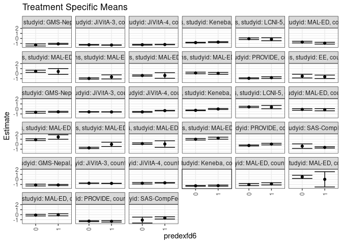

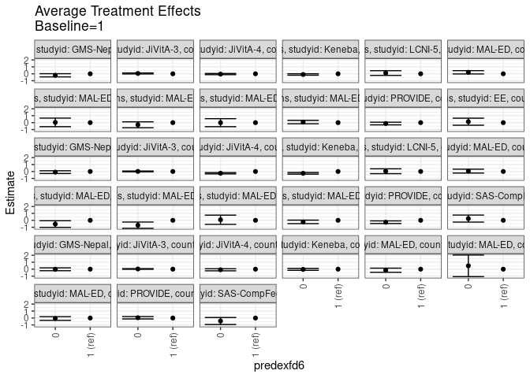

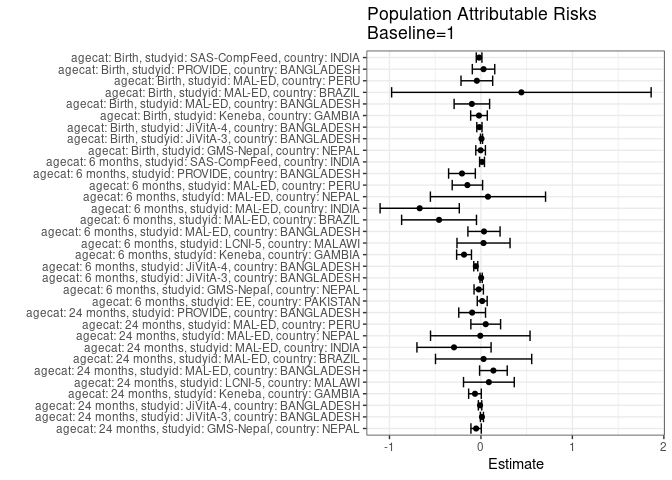

## Results Table

### Parameter: TSM

| agecat | studyid | country | intervention_level | baseline_level | estimate | ci_lower | ci_upper |
| --- | --- | --- | --- | --- | --- | --- | --- |
| Birth | GMS-Nepal | NEPAL | 1 | NA | -1.1030000 | -1.2190680 | -0.9869320 |
| Birth | GMS-Nepal | NEPAL | 0 | NA | -1.1166667 | -1.2888791 | -0.9444543 |
| Birth | JiVitA-3 | BANGLADESH | 1 | NA | -0.7872760 | -0.8123417 | -0.7622102 |
| Birth | JiVitA-3 | BANGLADESH | 0 | NA | -0.7576063 | -0.8030628 | -0.7121498 |
| Birth | JiVitA-4 | BANGLADESH | 1 | NA | -0.6738235 | -0.7291145 | -0.6185326 |
| Birth | JiVitA-4 | BANGLADESH | 0 | NA | -0.7614929 | -0.9032194 | -0.6197664 |
| Birth | Keneba | GAMBIA | 1 | NA | -1.2386000 | -1.3501230 | -1.1270770 |
| Birth | Keneba | GAMBIA | 0 | NA | -1.2709692 | -1.3512815 | -1.1906569 |
| Birth | MAL-ED | BANGLADESH | 1 | NA | -0.8763971 | -1.0943592 | -0.6584349 |
| Birth | MAL-ED | BANGLADESH | 0 | NA | -1.0290873 | -1.2328131 | -0.8253615 |
| Birth | MAL-ED | BRAZIL | 1 | NA | 0.0220000 | -1.4978207 | 1.5418207 |
| Birth | MAL-ED | BRAZIL | 0 | NA | 0.5069231 | 0.1803892 | 0.8334570 |
| Birth | MAL-ED | PERU | 1 | NA | -0.0141667 | -0.2233045 | 0.1949712 |
| Birth | MAL-ED | PERU | 0 | NA | -0.0824265 | -0.2444521 | 0.0795992 |
| Birth | PROVIDE | BANGLADESH | 1 | NA | -1.3269677 | -1.4749653 | -1.1789702 |
| Birth | PROVIDE | BANGLADESH | 0 | NA | -1.2867374 | -1.3764215 | -1.1970533 |
| Birth | SAS-CompFeed | INDIA | 1 | NA | -0.6397097 | -0.8621395 | -0.4172798 |
| Birth | SAS-CompFeed | INDIA | 0 | NA | -1.0713333 | -1.6580583 | -0.4846084 |
| 6 months | EE | PAKISTAN | 1 | NA | -0.6248062 | -0.9715960 | -0.2780164 |
| 6 months | EE | PAKISTAN | 0 | NA | -0.4893333 | -0.8590751 | -0.1195916 |
| 6 months | GMS-Nepal | NEPAL | 1 | NA | -0.5767365 | -0.6790365 | -0.4744364 |
| 6 months | GMS-Nepal | NEPAL | 0 | NA | -0.6705437 | -0.8404121 | -0.5006754 |
| 6 months | JiVitA-3 | BANGLADESH | 1 | NA | -0.6025738 | -0.6300487 | -0.5750989 |
| 6 months | JiVitA-3 | BANGLADESH | 0 | NA | -0.5918742 | -0.6383218 | -0.5454265 |
| 6 months | JiVitA-4 | BANGLADESH | 1 | NA | -0.3405816 | -0.3852497 | -0.2959135 |
| 6 months | JiVitA-4 | BANGLADESH | 0 | NA | -0.5943038 | -0.6776480 | -0.5109596 |
| 6 months | Keneba | GAMBIA | 1 | NA | -0.0152156 | -0.1135250 | 0.0830938 |
| 6 months | Keneba | GAMBIA | 0 | NA | -0.2815693 | -0.3445913 | -0.2185474 |
| 6 months | LCNI-5 | MALAWI | 1 | NA | 0.3642553 | 0.0371861 | 0.6913246 |
| 6 months | LCNI-5 | MALAWI | 0 | NA | 0.3984000 | 0.2718569 | 0.5249431 |
| 6 months | MAL-ED | BANGLADESH | 1 | NA | -0.1547222 | -0.3759417 | 0.0664972 |
| 6 months | MAL-ED | BANGLADESH | 0 | NA | -0.1022336 | -0.2678376 | 0.0633705 |
| 6 months | MAL-ED | BRAZIL | 1 | NA | 1.4299444 | 0.9860894 | 1.8737995 |
| 6 months | MAL-ED | BRAZIL | 0 | NA | 0.8953399 | 0.7210809 | 1.0695988 |
| 6 months | MAL-ED | INDIA | 1 | NA | -0.0372727 | -0.4728155 | 0.3982700 |
| 6 months | MAL-ED | INDIA | 0 | NA | -0.7423068 | -0.8756972 | -0.6089163 |
| 6 months | MAL-ED | NEPAL | 1 | NA | 0.0320833 | -0.6183088 | 0.6824755 |
| 6 months | MAL-ED | NEPAL | 0 | NA | 0.1134820 | -0.0250715 | 0.2520355 |
| 6 months | MAL-ED | PERU | 1 | NA | 1.1985145 | 1.0001130 | 1.3969159 |
| 6 months | MAL-ED | PERU | 0 | NA | 0.9745996 | 0.8210073 | 1.1281920 |
| 6 months | PROVIDE | BANGLADESH | 1 | NA | 0.0081915 | -0.1568998 | 0.1732827 |
| 6 months | PROVIDE | BANGLADESH | 0 | NA | -0.2623521 | -0.3570701 | -0.1676341 |
| 6 months | SAS-CompFeed | INDIA | 1 | NA | -0.6469149 | -0.7835786 | -0.5102511 |
| 6 months | SAS-CompFeed | INDIA | 0 | NA | -0.3968421 | -0.8495292 | 0.0558450 |
| 24 months | GMS-Nepal | NEPAL | 1 | NA | -1.0898075 | -1.1896297 | -0.9899853 |
| 24 months | GMS-Nepal | NEPAL | 0 | NA | -1.3059795 | -1.5138227 | -1.0981364 |
| 24 months | JiVitA-3 | BANGLADESH | 1 | NA | -1.3212714 | -1.3564456 | -1.2860972 |
| 24 months | JiVitA-3 | BANGLADESH | 0 | NA | -1.2734283 | -1.3372030 | -1.2096536 |
| 24 months | JiVitA-4 | BANGLADESH | 1 | NA | -1.2170775 | -1.2563914 | -1.1777636 |
| 24 months | JiVitA-4 | BANGLADESH | 0 | NA | -1.2607395 | -1.3379837 | -1.1834953 |
| 24 months | Keneba | GAMBIA | 1 | NA | -0.7381832 | -0.8224240 | -0.6539424 |
| 24 months | Keneba | GAMBIA | 0 | NA | -0.8366685 | -0.8987548 | -0.7745822 |
| 24 months | LCNI-5 | MALAWI | 1 | NA | -0.1641176 | -0.4633222 | 0.1350870 |
| 24 months | LCNI-5 | MALAWI | 0 | NA | -0.0573333 | -0.2194120 | 0.1047453 |
| 24 months | MAL-ED | BANGLADESH | 1 | NA | -0.9534211 | -1.1293789 | -0.7774632 |
| 24 months | MAL-ED | BANGLADESH | 0 | NA | -0.7365891 | -0.8984919 | -0.5746863 |
| 24 months | MAL-ED | BRAZIL | 1 | NA | 0.4334000 | -0.1432978 | 1.0100978 |
| 24 months | MAL-ED | BRAZIL | 0 | NA | 0.4676968 | 0.2478121 | 0.6875815 |
| 24 months | MAL-ED | INDIA | 1 | NA | -0.6500000 | -1.0593866 | -0.2406134 |
| 24 months | MAL-ED | INDIA | 0 | NA | -0.9606061 | -1.0847993 | -0.8364128 |
| 24 months | MAL-ED | NEPAL | 1 | NA | -0.3604167 | -0.9235036 | 0.2026703 |
| 24 months | MAL-ED | NEPAL | 0 | NA | -0.3678502 | -0.4868476 | -0.2488529 |
| 24 months | MAL-ED | PERU | 1 | NA | 0.0586642 | -0.1277269 | 0.2450553 |
| 24 months | MAL-ED | PERU | 0 | NA | 0.1380576 | -0.0214161 | 0.2975314 |
| 24 months | PROVIDE | BANGLADESH | 1 | NA | -0.7967883 | -0.9631693 | -0.6304074 |
| 24 months | PROVIDE | BANGLADESH | 0 | NA | -0.9226471 | -1.0176695 | -0.8276246 |

### Parameter: E(Y)

| agecat | studyid | country | intervention_level | baseline_level | estimate | ci_lower | ci_upper |
| --- | --- | --- | --- | --- | --- | --- | --- |
| Birth | GMS-Nepal | NEPAL | NA | NA | -1.1064559 | -1.2034951 | -1.0094168 |
| Birth | JiVitA-3 | BANGLADESH | NA | NA | -0.7807809 | -0.8030521 | -0.7585097 |
| Birth | JiVitA-4 | BANGLADESH | NA | NA | -0.6904586 | -0.7435822 | -0.6373351 |
| Birth | Keneba | GAMBIA | NA | NA | -1.2599925 | -1.3251703 | -1.1948146 |
| Birth | MAL-ED | BANGLADESH | NA | NA | -0.9755670 | -1.1287016 | -0.8224325 |
| Birth | MAL-ED | BRAZIL | NA | NA | 0.4643860 | 0.1360519 | 0.7927200 |
| Birth | MAL-ED | PERU | NA | NA | -0.0587981 | -0.1871869 | 0.0695908 |
| Birth | PROVIDE | BANGLADESH | NA | NA | -1.2984586 | -1.3752758 | -1.2216415 |
| Birth | SAS-CompFeed | INDIA | NA | NA | -0.6596308 | -0.9005716 | -0.4186900 |
| 6 months | EE | PAKISTAN | NA | NA | -0.6106944 | -0.9239621 | -0.2974268 |
| 6 months | GMS-Nepal | NEPAL | NA | NA | -0.6009171 | -0.6886356 | -0.5131986 |
| 6 months | JiVitA-3 | BANGLADESH | NA | NA | -0.6001300 | -0.6240378 | -0.5762223 |
| 6 months | JiVitA-4 | BANGLADESH | NA | NA | -0.3968456 | -0.4358721 | -0.3578192 |
| 6 months | Keneba | GAMBIA | NA | NA | -0.1997647 | -0.2531388 | -0.1463906 |
| 6 months | LCNI-5 | MALAWI | NA | NA | 0.3925000 | 0.2735307 | 0.5114693 |
| 6 months | MAL-ED | BANGLADESH | NA | NA | -0.1213203 | -0.2539388 | 0.0112981 |
| 6 months | MAL-ED | BRAZIL | NA | NA | 0.9720774 | 0.8078144 | 1.1363403 |
| 6 months | MAL-ED | INDIA | NA | NA | -0.7067317 | -0.8369134 | -0.5765499 |
| 6 months | MAL-ED | NEPAL | NA | NA | 0.1091407 | -0.0265536 | 0.2448351 |
| 6 months | MAL-ED | PERU | NA | NA | 1.0506150 | 0.9281868 | 1.1730433 |
| 6 months | PROVIDE | BANGLADESH | NA | NA | -0.1990907 | -0.2817968 | -0.1163845 |
| 6 months | SAS-CompFeed | INDIA | NA | NA | -0.6348861 | -0.7630511 | -0.5067211 |
| 24 months | GMS-Nepal | NEPAL | NA | NA | -1.1423525 | -1.2336321 | -1.0510729 |
| 24 months | JiVitA-3 | BANGLADESH | NA | NA | -1.3103375 | -1.3408810 | -1.2797940 |
| 24 months | JiVitA-4 | BANGLADESH | NA | NA | -1.2265320 | -1.2620508 | -1.1910132 |
| 24 months | Keneba | GAMBIA | NA | NA | -0.8032329 | -0.8532842 | -0.7531817 |
| 24 months | LCNI-5 | MALAWI | NA | NA | -0.0770652 | -0.2204213 | 0.0662909 |
| 24 months | MAL-ED | BANGLADESH | NA | NA | -0.8169756 | -0.9388013 | -0.6951499 |
| 24 months | MAL-ED | BRAZIL | NA | NA | 0.4626233 | 0.2567495 | 0.6684971 |
| 24 months | MAL-ED | INDIA | NA | NA | -0.9442584 | -1.0642426 | -0.8242742 |
| 24 months | MAL-ED | NEPAL | NA | NA | -0.3674429 | -0.4840752 | -0.2508107 |
| 24 months | MAL-ED | PERU | NA | NA | 0.1111982 | -0.0118399 | 0.2342362 |
| 24 months | PROVIDE | BANGLADESH | NA | NA | -0.8928670 | -0.9755153 | -0.8102187 |

### Parameter: ATE

| agecat | studyid | country | intervention_level | baseline_level | estimate | ci_lower | ci_upper |
| --- | --- | --- | --- | --- | --- | --- | --- |
| Birth | GMS-Nepal | NEPAL | 1 | 1 | 0.0000000 | 0.0000000 | 0.0000000 |
| Birth | GMS-Nepal | NEPAL | 0 | 1 | -0.0136667 | -0.2213416 | 0.1940083 |
| Birth | JiVitA-3 | BANGLADESH | 1 | 1 | 0.0000000 | 0.0000000 | 0.0000000 |
| Birth | JiVitA-3 | BANGLADESH | 0 | 1 | 0.0296697 | -0.0214215 | 0.0807609 |
| Birth | JiVitA-4 | BANGLADESH | 1 | 1 | 0.0000000 | 0.0000000 | 0.0000000 |
| Birth | JiVitA-4 | BANGLADESH | 0 | 1 | -0.0876694 | -0.2375697 | 0.0622309 |
| Birth | Keneba | GAMBIA | 1 | 1 | 0.0000000 | 0.0000000 | 0.0000000 |
| Birth | Keneba | GAMBIA | 0 | 1 | -0.0323692 | -0.1698008 | 0.1050623 |
| Birth | MAL-ED | BANGLADESH | 1 | 1 | 0.0000000 | 0.0000000 | 0.0000000 |
| Birth | MAL-ED | BANGLADESH | 0 | 1 | -0.1526902 | -0.4510385 | 0.1456580 |
| Birth | MAL-ED | BRAZIL | 1 | 1 | 0.0000000 | 0.0000000 | 0.0000000 |
| Birth | MAL-ED | BRAZIL | 0 | 1 | 0.4849231 | -1.0695798 | 2.0394260 |
| Birth | MAL-ED | PERU | 1 | 1 | 0.0000000 | 0.0000000 | 0.0000000 |
| Birth | MAL-ED | PERU | 0 | 1 | -0.0682598 | -0.3328178 | 0.1962982 |
| Birth | PROVIDE | BANGLADESH | 1 | 1 | 0.0000000 | 0.0000000 | 0.0000000 |
| Birth | PROVIDE | BANGLADESH | 0 | 1 | 0.0402303 | -0.1328202 | 0.2132809 |
| Birth | SAS-CompFeed | INDIA | 1 | 1 | 0.0000000 | 0.0000000 | 0.0000000 |
| Birth | SAS-CompFeed | INDIA | 0 | 1 | -0.4316237 | -0.9347060 | 0.0714587 |
| 6 months | EE | PAKISTAN | 1 | 1 | 0.0000000 | 0.0000000 | 0.0000000 |
| 6 months | EE | PAKISTAN | 0 | 1 | 0.1354729 | -0.3714513 | 0.6423970 |
| 6 months | GMS-Nepal | NEPAL | 1 | 1 | 0.0000000 | 0.0000000 | 0.0000000 |
| 6 months | GMS-Nepal | NEPAL | 0 | 1 | -0.0938073 | -0.2921014 | 0.1044868 |
| 6 months | JiVitA-3 | BANGLADESH | 1 | 1 | 0.0000000 | 0.0000000 | 0.0000000 |
| 6 months | JiVitA-3 | BANGLADESH | 0 | 1 | 0.0106996 | -0.0427880 | 0.0641872 |
| 6 months | JiVitA-4 | BANGLADESH | 1 | 1 | 0.0000000 | 0.0000000 | 0.0000000 |
| 6 months | JiVitA-4 | BANGLADESH | 0 | 1 | -0.2537222 | -0.3490933 | -0.1583510 |
| 6 months | Keneba | GAMBIA | 1 | 1 | 0.0000000 | 0.0000000 | 0.0000000 |
| 6 months | Keneba | GAMBIA | 0 | 1 | -0.2663537 | -0.3831291 | -0.1495783 |
| 6 months | LCNI-5 | MALAWI | 1 | 1 | 0.0000000 | 0.0000000 | 0.0000000 |
| 6 months | LCNI-5 | MALAWI | 0 | 1 | 0.0341447 | -0.3165510 | 0.3848404 |
| 6 months | MAL-ED | BANGLADESH | 1 | 1 | 0.0000000 | 0.0000000 | 0.0000000 |
| 6 months | MAL-ED | BANGLADESH | 0 | 1 | 0.0524887 | -0.2238494 | 0.3288268 |
| 6 months | MAL-ED | BRAZIL | 1 | 1 | 0.0000000 | 0.0000000 | 0.0000000 |
| 6 months | MAL-ED | BRAZIL | 0 | 1 | -0.5346046 | -1.0114415 | -0.0577677 |
| 6 months | MAL-ED | INDIA | 1 | 1 | 0.0000000 | 0.0000000 | 0.0000000 |
| 6 months | MAL-ED | INDIA | 0 | 1 | -0.7050340 | -1.1605453 | -0.2495228 |
| 6 months | MAL-ED | NEPAL | 1 | 1 | 0.0000000 | 0.0000000 | 0.0000000 |
| 6 months | MAL-ED | NEPAL | 0 | 1 | 0.0813987 | -0.5835878 | 0.7463851 |
| 6 months | MAL-ED | PERU | 1 | 1 | 0.0000000 | 0.0000000 | 0.0000000 |
| 6 months | MAL-ED | PERU | 0 | 1 | -0.2239149 | -0.4748207 | 0.0269910 |
| 6 months | PROVIDE | BANGLADESH | 1 | 1 | 0.0000000 | 0.0000000 | 0.0000000 |
| 6 months | PROVIDE | BANGLADESH | 0 | 1 | -0.2705436 | -0.4608765 | -0.0802107 |
| 6 months | SAS-CompFeed | INDIA | 1 | 1 | 0.0000000 | 0.0000000 | 0.0000000 |
| 6 months | SAS-CompFeed | INDIA | 0 | 1 | 0.2500728 | -0.2551626 | 0.7553082 |
| 24 months | GMS-Nepal | NEPAL | 1 | 1 | 0.0000000 | 0.0000000 | 0.0000000 |
| 24 months | GMS-Nepal | NEPAL | 0 | 1 | -0.2161720 | -0.4467436 | 0.0143996 |
| 24 months | JiVitA-3 | BANGLADESH | 1 | 1 | 0.0000000 | 0.0000000 | 0.0000000 |
| 24 months | JiVitA-3 | BANGLADESH | 0 | 1 | 0.0478431 | -0.0255060 | 0.1211922 |
| 24 months | JiVitA-4 | BANGLADESH | 1 | 1 | 0.0000000 | 0.0000000 | 0.0000000 |
| 24 months | JiVitA-4 | BANGLADESH | 0 | 1 | -0.0436620 | -0.1292725 | 0.0419485 |
| 24 months | Keneba | GAMBIA | 1 | 1 | 0.0000000 | 0.0000000 | 0.0000000 |
| 24 months | Keneba | GAMBIA | 0 | 1 | -0.0984853 | -0.2031334 | 0.0061628 |
| 24 months | LCNI-5 | MALAWI | 1 | 1 | 0.0000000 | 0.0000000 | 0.0000000 |
| 24 months | LCNI-5 | MALAWI | 0 | 1 | 0.1067843 | -0.2334992 | 0.4470678 |
| 24 months | MAL-ED | BANGLADESH | 1 | 1 | 0.0000000 | 0.0000000 | 0.0000000 |
| 24 months | MAL-ED | BANGLADESH | 0 | 1 | 0.2168319 | -0.0222783 | 0.4559421 |
| 24 months | MAL-ED | BRAZIL | 1 | 1 | 0.0000000 | 0.0000000 | 0.0000000 |
| 24 months | MAL-ED | BRAZIL | 0 | 1 | 0.0342968 | -0.5828982 | 0.6514918 |
| 24 months | MAL-ED | INDIA | 1 | 1 | 0.0000000 | 0.0000000 | 0.0000000 |
| 24 months | MAL-ED | INDIA | 0 | 1 | -0.3106061 | -0.7384160 | 0.1172039 |
| 24 months | MAL-ED | NEPAL | 1 | 1 | 0.0000000 | 0.0000000 | 0.0000000 |
| 24 months | MAL-ED | NEPAL | 0 | 1 | -0.0074336 | -0.5829571 | 0.5680899 |
| 24 months | MAL-ED | PERU | 1 | 1 | 0.0000000 | 0.0000000 | 0.0000000 |
| 24 months | MAL-ED | PERU | 0 | 1 | 0.0793934 | -0.1659095 | 0.3246963 |
| 24 months | PROVIDE | BANGLADESH | 1 | 1 | 0.0000000 | 0.0000000 | 0.0000000 |
| 24 months | PROVIDE | BANGLADESH | 0 | 1 | -0.1258587 | -0.3174622 | 0.0657447 |

### Parameter: PAR

| agecat | studyid | country | intervention_level | baseline_level | estimate | ci_lower | ci_upper |
| --- | --- | --- | --- | --- | --- | --- | --- |
| Birth | GMS-Nepal | NEPAL | 1 | NA | -0.0034559 | -0.0559739 | 0.0490620 |
| Birth | JiVitA-3 | BANGLADESH | 1 | NA | 0.0064951 | -0.0046857 | 0.0176759 |
| Birth | JiVitA-4 | BANGLADESH | 1 | NA | -0.0166351 | -0.0449768 | 0.0117066 |
| Birth | Keneba | GAMBIA | 1 | NA | -0.0213925 | -0.1122232 | 0.0694383 |
| Birth | MAL-ED | BANGLADESH | 1 | NA | -0.0991700 | -0.2932149 | 0.0948750 |
| Birth | MAL-ED | BRAZIL | 1 | NA | 0.4423860 | -0.9762121 | 1.8609840 |
| Birth | MAL-ED | PERU | 1 | NA | -0.0446314 | -0.2176682 | 0.1284054 |
| Birth | PROVIDE | BANGLADESH | 1 | NA | 0.0285091 | -0.0941325 | 0.1511507 |
| Birth | SAS-CompFeed | INDIA | 1 | NA | -0.0199211 | -0.0507808 | 0.0109386 |
| 6 months | EE | PAKISTAN | 1 | NA | 0.0141118 | -0.0400020 | 0.0682256 |
| 6 months | GMS-Nepal | NEPAL | 1 | NA | -0.0241807 | -0.0754106 | 0.0270493 |
| 6 months | JiVitA-3 | BANGLADESH | 1 | NA | 0.0024437 | -0.0097742 | 0.0146616 |
| 6 months | JiVitA-4 | BANGLADESH | 1 | NA | -0.0562640 | -0.0780199 | -0.0345081 |
| 6 months | Keneba | GAMBIA | 1 | NA | -0.1845491 | -0.2656472 | -0.1034509 |
| 6 months | LCNI-5 | MALAWI | 1 | NA | 0.0282447 | -0.2618569 | 0.3183463 |
| 6 months | MAL-ED | BANGLADESH | 1 | NA | 0.0334019 | -0.1424799 | 0.2092837 |
| 6 months | MAL-ED | BRAZIL | 1 | NA | -0.4578671 | -0.8670522 | -0.0486820 |
| 6 months | MAL-ED | INDIA | 1 | NA | -0.6694589 | -1.1024728 | -0.2364451 |
| 6 months | MAL-ED | NEPAL | 1 | NA | 0.0770574 | -0.5524677 | 0.7065825 |
| 6 months | MAL-ED | PERU | 1 | NA | -0.1478995 | -0.3141088 | 0.0183099 |
| 6 months | PROVIDE | BANGLADESH | 1 | NA | -0.2072821 | -0.3533960 | -0.0611683 |
| 6 months | SAS-CompFeed | INDIA | 1 | NA | 0.0120288 | -0.0145556 | 0.0386132 |
| 24 months | GMS-Nepal | NEPAL | 1 | NA | -0.0525450 | -0.1092162 | 0.0041262 |
| 24 months | JiVitA-3 | BANGLADESH | 1 | NA | 0.0109339 | -0.0058021 | 0.0276700 |
| 24 months | JiVitA-4 | BANGLADESH | 1 | NA | -0.0094545 | -0.0280461 | 0.0091370 |
| 24 months | Keneba | GAMBIA | 1 | NA | -0.0650497 | -0.1342099 | 0.0041105 |
| 24 months | LCNI-5 | MALAWI | 1 | NA | 0.0870524 | -0.1904176 | 0.3645225 |
| 24 months | MAL-ED | BANGLADESH | 1 | NA | 0.1364454 | -0.0147038 | 0.2875947 |
| 24 months | MAL-ED | BRAZIL | 1 | NA | 0.0292233 | -0.4966739 | 0.5551205 |
| 24 months | MAL-ED | INDIA | 1 | NA | -0.2942584 | -0.6996616 | 0.1111449 |
| 24 months | MAL-ED | NEPAL | 1 | NA | -0.0070263 | -0.5510143 | 0.5369617 |
| 24 months | MAL-ED | PERU | 1 | NA | 0.0525340 | -0.1098644 | 0.2149323 |
| 24 months | PROVIDE | BANGLADESH | 1 | NA | -0.0960787 | -0.2424109 | 0.0502535 |